# West Nile Virus Forecast Report for 2018-08-15 South Dakota

#### 3.1.6.2 Anomalized weather with fixed cubic splines: “cub-fx-anom”

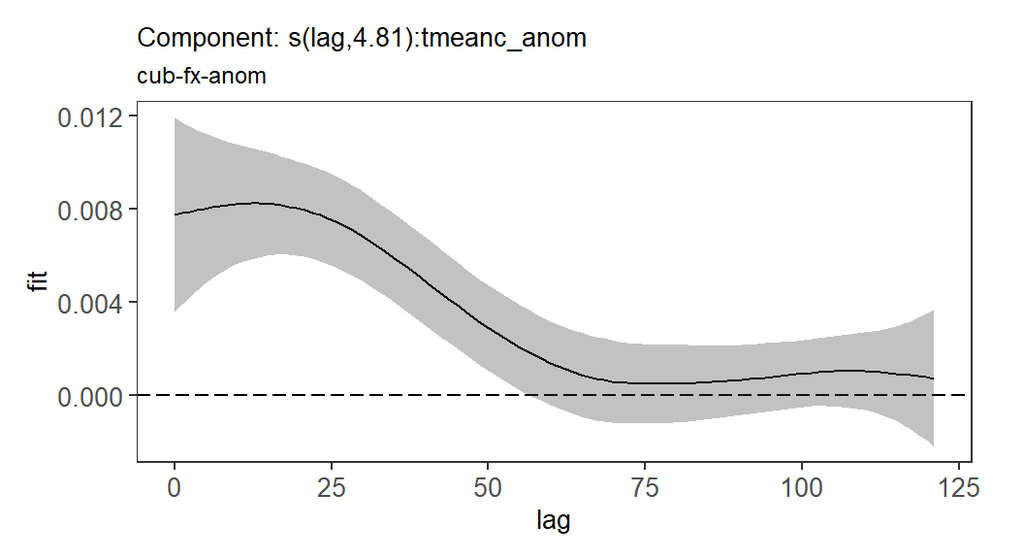

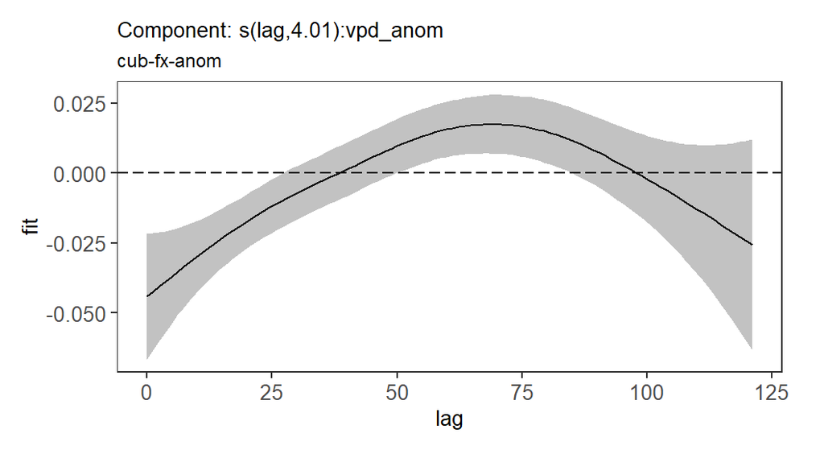

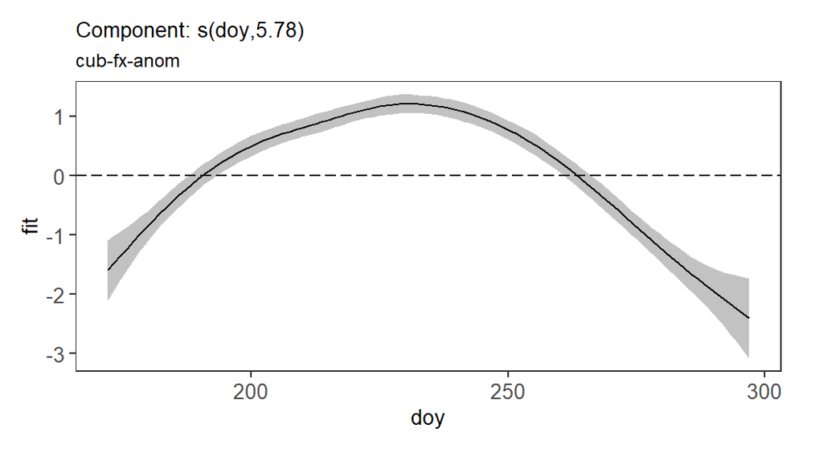

#### 3.1.6.3 Non-anomalized weather with seasonally-varying cubic splines: “cub-sv-nonanom”

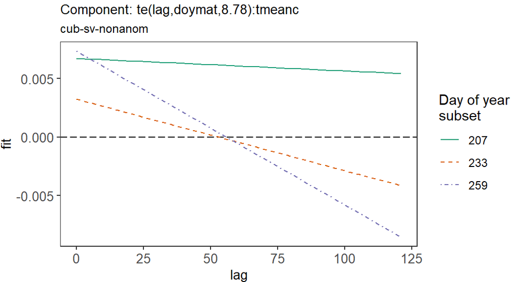

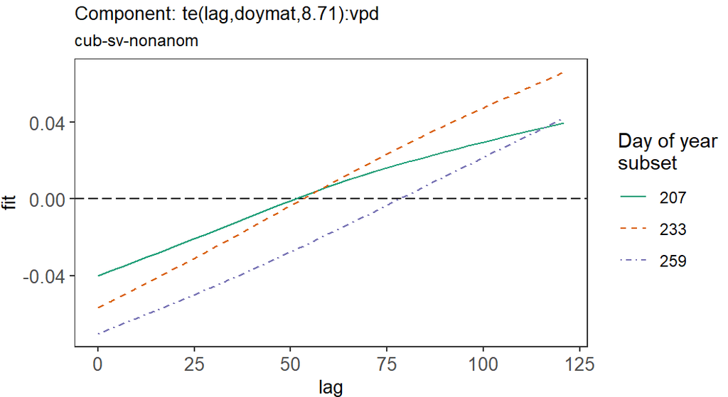

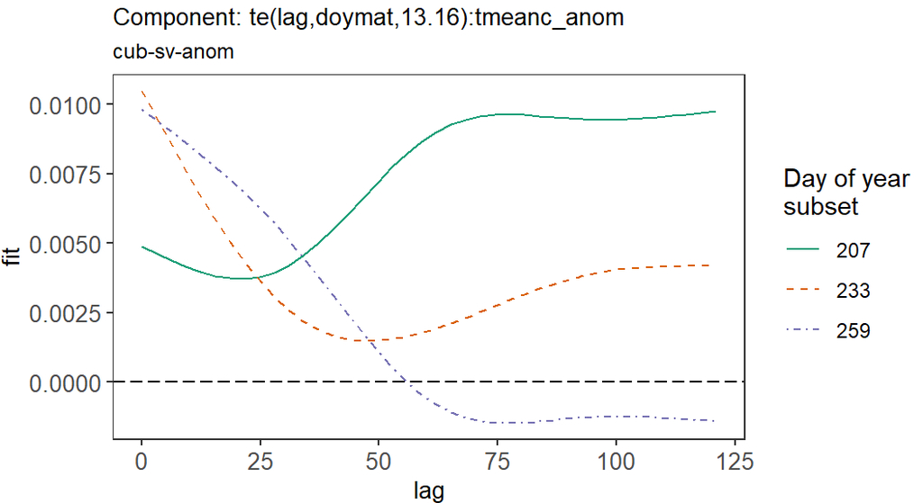

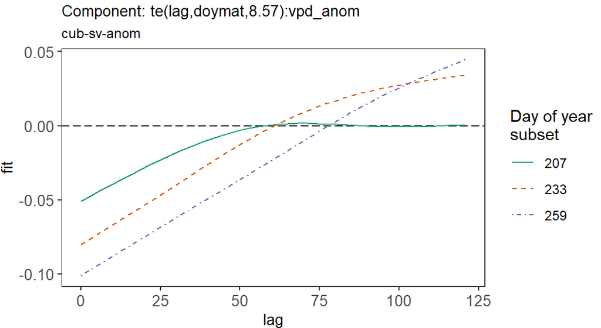

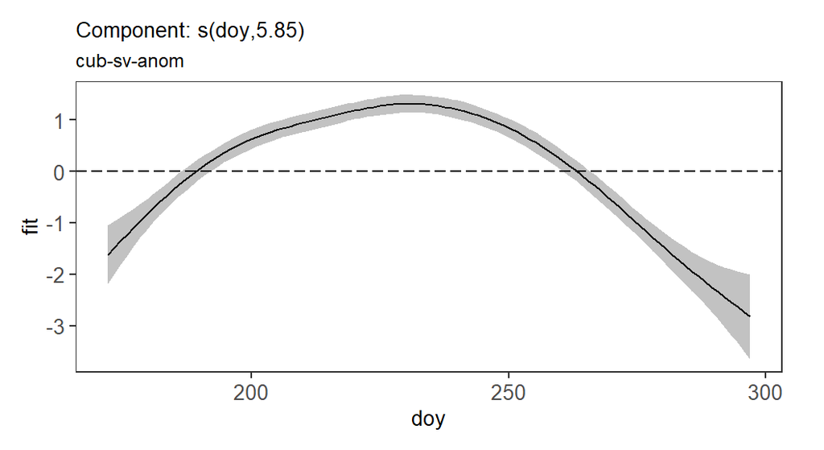

#### 3.1.6.5 Non-anomalized weather with fixed thin plate splines: “tp-fx-nonanom”

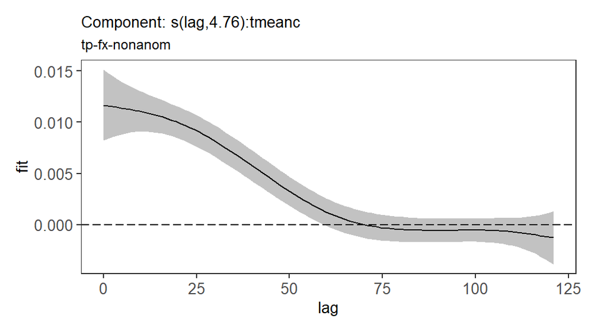

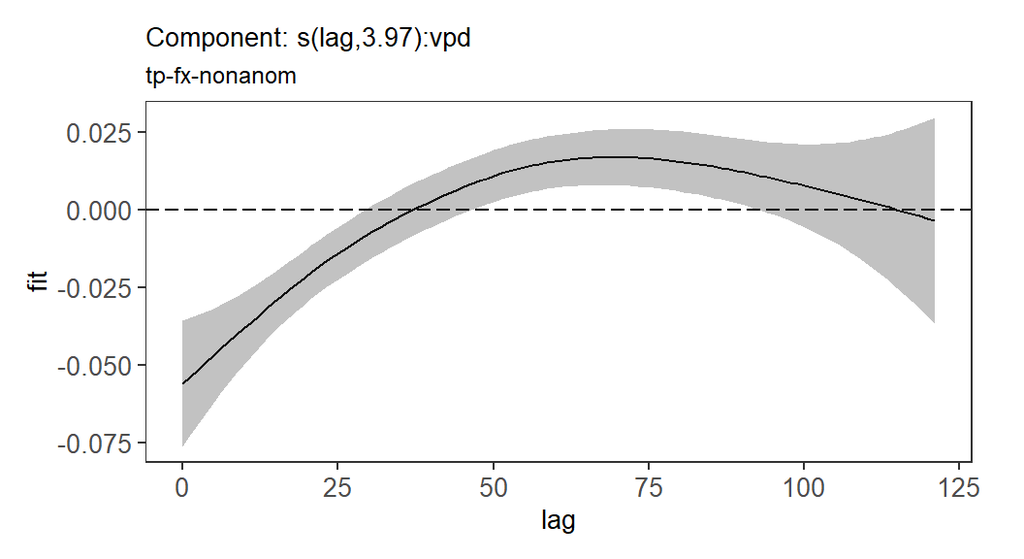

#### 3.1.6.6 Anomalized weather with fixed thin plate splines: “tp-fx-anom”

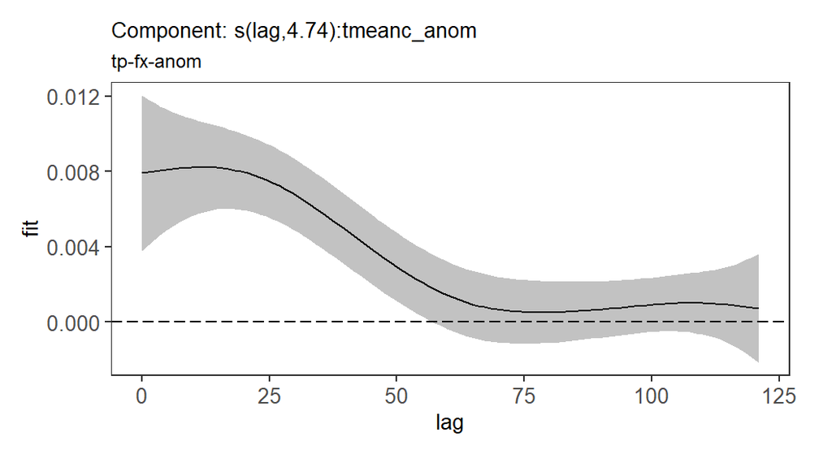

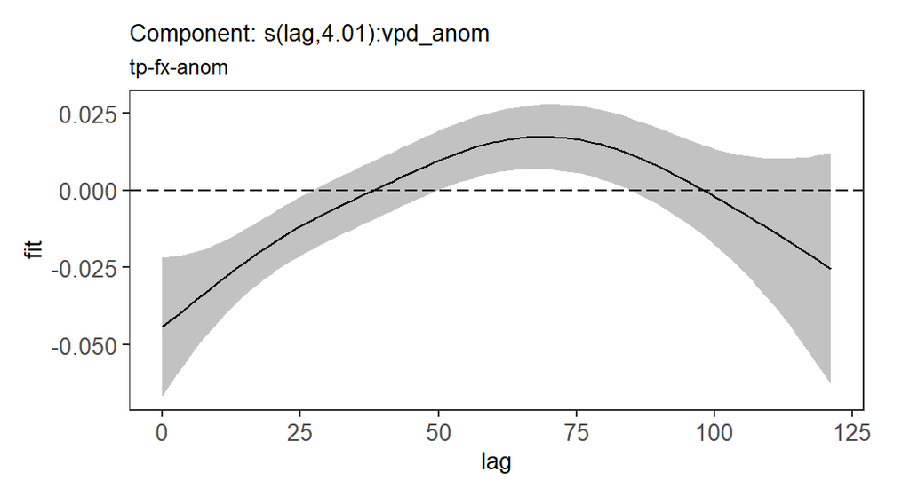

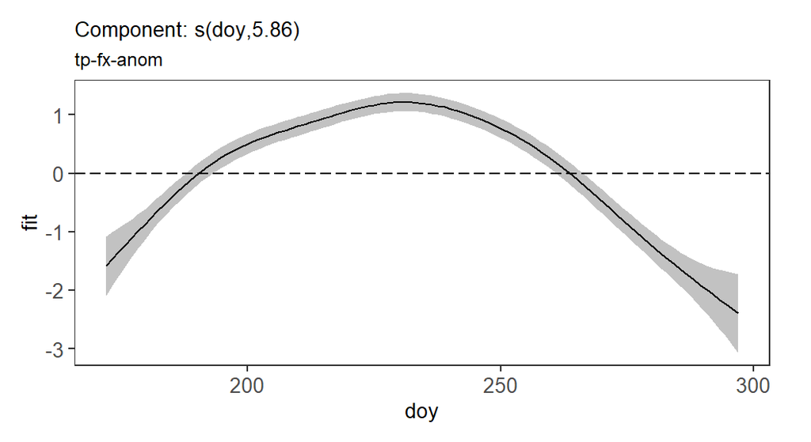

#### 3.1.6.7 Non-anomalized weather with seasonally-varying thin plate splines: “tp-sv-nonanom”

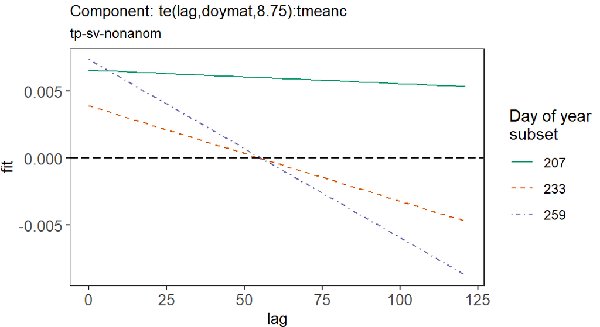

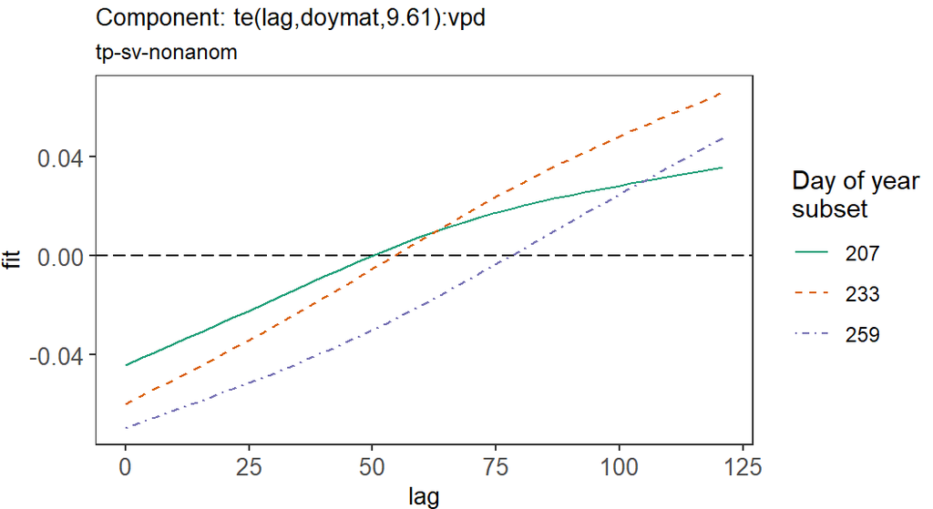

#### 3.1.6.8 Anomalized weather with seasonally-varying thin plate splines: “tp-sv-anom”

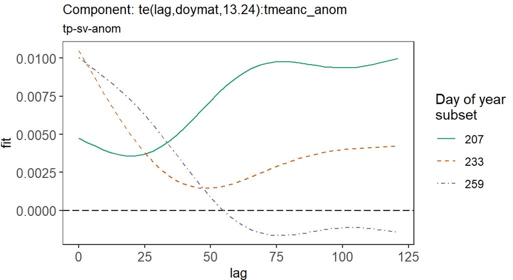

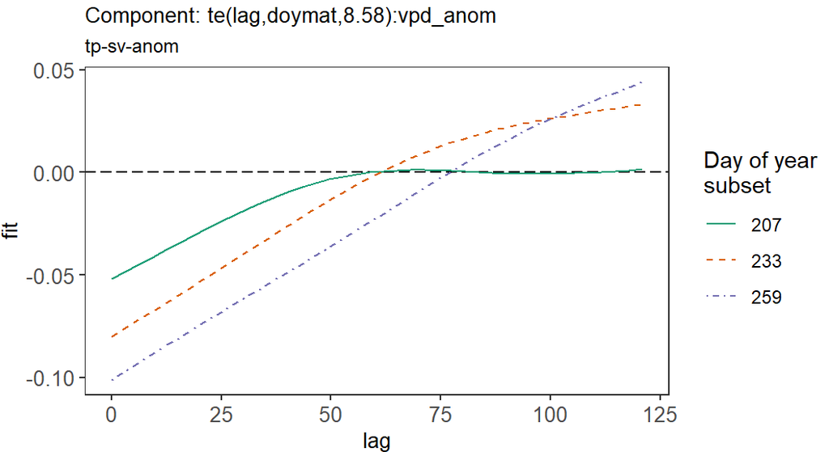

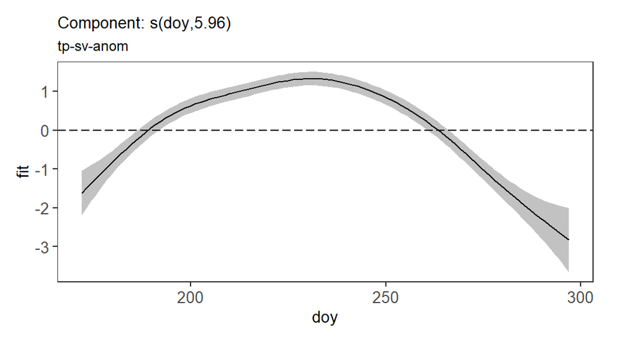

### 3.1.7 Multi-year forecasts

The graph below shows the full forecast for all years, with lines for **each** model:

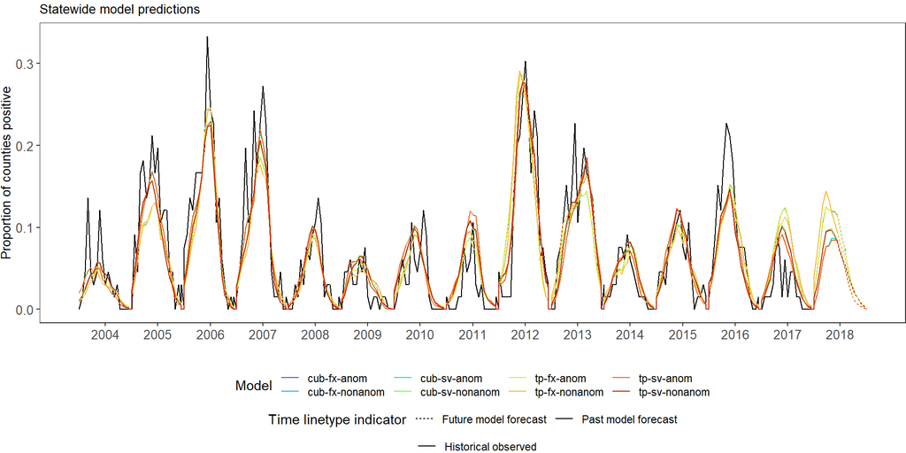

### 3.1.8 Models and formulas

The table below lists the models that were found in the models file. Standard models will have a text description, but all models run should appear in the table along with their formula.

The following fields may be present:

- `any_cases` : positive county-week
- `arbo_ID` : internal field for identifying counties
- `mir_stat` : the mosquito infection rate statistic
- `s(lag, by=var...)` : fixed smooth term for the environmental variable over the distributed lag period
- `te(lag, doymat, by=var...)` : seasonally-varying smooth term for the environmental variable over the distributed lag period
- `var1` : variable for tmeanc, observed value
- `var2` : variable for vpd, observed value
- `var1_anom` : variable for tmeanc, anomalized value
- `var2_anom` : variable for vpd, anomalized value
- `s(doy,...)` : smooth term for day of year, for seasonality

[output not shown]

## 3.2 Data summaries

### 3.2.1 Anomalized environmental variables

The report parameters set the two environmental predictor variables as tmeanc and vpd. The following two graphs show the median state-wide anomalized weather variables for the forecast year, compared to the historical median. Anomalies are calculated using deviance between the observed value and the predicted value from a GAM regression model using county and a smooth on day of year (seasonality) and county. An anomaly is the observed minus the predicted.

Two or more consecutive days that have anomalized values **greater** than the anomalized historical median are drawn in red and consecutive days that are **less** than the historical median are drawn in blue. Consecutive days that overlap the historical median (i.e. one day above and the next below, or the opposite) are in purple. The gray shaded region is a ribbon showing the historical range (min to max).

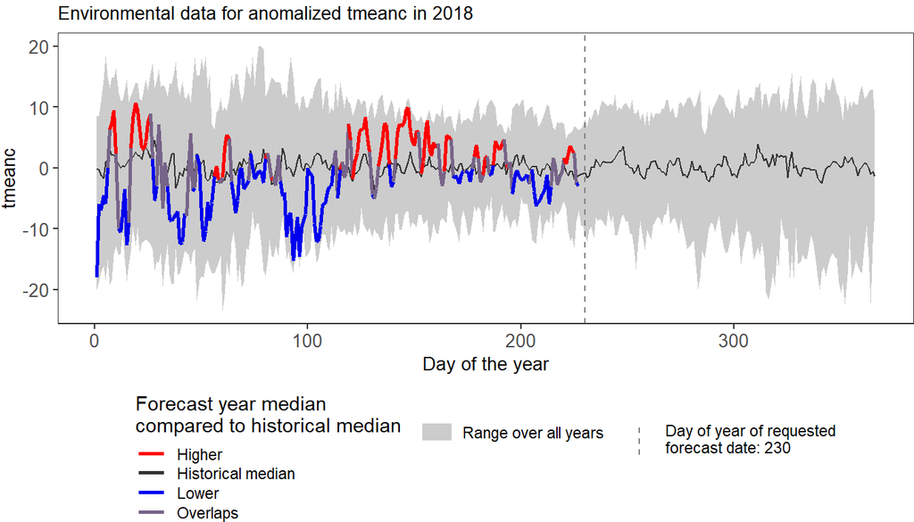

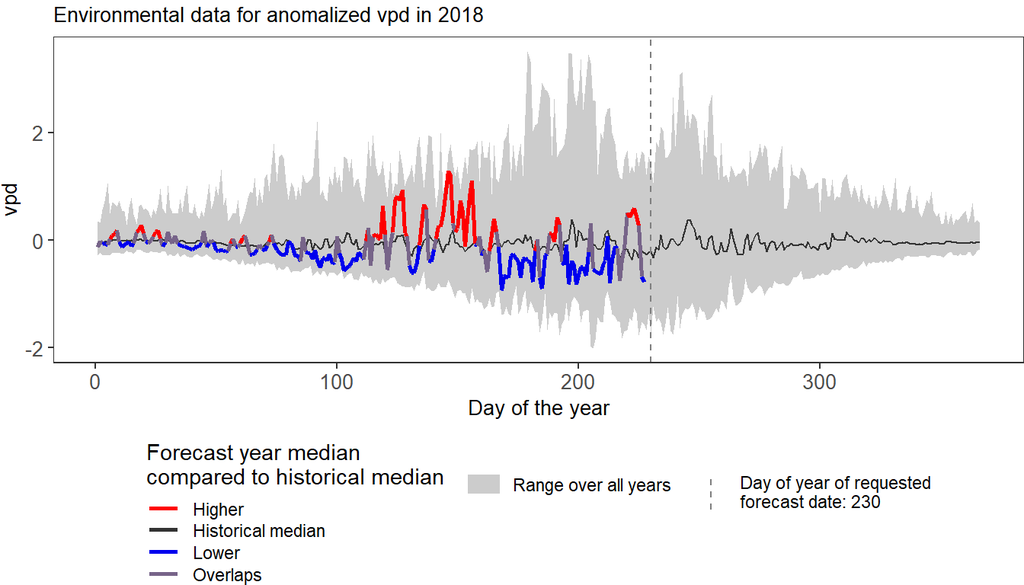

### 3.2.2 Modeled mosquito infection rate

In modeling years where sufficient mosquito data were present, the mosquito infection rate (MIR) statistic was created using the model specified in the input parameter: stratifiedMIGR. The following table presents these raw calculated MIR values and then the MIR values that were used in the forecast modeling after imputation for unknown years and centering. Imputation was done via a linear model between known MIR values and the total human cases (interacting with strata if using a stratified model). If the current forecast year had no mosquito data yet, it was assumed to have an average risk (MIR = 0).

Mosquito model summary statistic

| Year | Stratum | Raw MIR stat | Imputed and centered MIR stat |
| --- | --- | --- | --- |
| 2004 | 101 | 0.317 | 0.300 |
| 2005 | 101 | 0.688 | 0.671 |
| 2006 | 101 | 1.364 | 1.347 |
| 2007 | 101 | 0.318 | 0.302 |
| 2008 | 101 | -0.357 | -0.374 |
| 2009 | 101 | -0.328 | -0.345 |
| 2010 | 101 | -0.912 | -0.929 |
| 2011 | 101 | -1.648 | -1.665 |
| 2012 | 101 | 0.427 | 0.410 |
| 2013 | 101 | 1.100 | 1.083 |
| 2014 | 101 | 0.434 | 0.417 |
| 2015 | 101 | -0.429 | -0.446 |
| 2016 | 101 | 0.038 | 0.021 |
| 2017 | 101 | -0.229 | -0.246 |
| 2018 | 101 | -0.012 | -0.029 |
| 2004 | 102 | - | -0.316 |
| 2005 | 102 | 0.271 | 0.254 |
| 2006 | 102 | 0.364 | 0.347 |
| 2007 | 102 | 0.681 | 0.665 |
| 2008 | 102 | -0.558 | -0.575 |
| 2009 | 102 | 0.411 | 0.394 |
| 2010 | 102 | -0.877 | -0.893 |
| 2011 | 102 | -1.446 | -1.463 |
| 2012 | 102 | 1.494 | 1.477 |
| 2013 | 102 | 0.851 | 0.835 |
| 2014 | 102 | 0.170 | 0.153 |
| 2015 | 102 | 0.314 | 0.297 |
| 2016 | 102 | 0.636 | 0.619 |
| 2017 | 102 | 0.399 | 0.382 |
| 2018 | 102 | 0.372 | 0.355 |
| 2004 | 103 | - | -0.258 |
| 2005 | 103 | -0.741 | -0.758 |
| 2006 | 103 | 0.276 | 0.259 |
| 2007 | 103 | 0.367 | 0.350 |
| 2008 | 103 | 0.320 | 0.303 |
| 2009 | 103 | -0.040 | -0.056 |
| 2010 | 103 | 0.330 | 0.314 |
| 2011 | 103 | -1.205 | -1.222 |
| 2012 | 103 | 0.906 | 0.889 |
| 2013 | 103 | 1.321 | 1.304 |
| 2014 | 103 | -0.105 | -0.122 |
| 2015 | 103 | 0.356 | 0.339 |
| 2016 | 103 | -0.363 | -0.380 |
| 2017 | 103 | 0.125 | 0.108 |
| 2018 | 103 | -0.245 | -0.262 |
| 2004 | 104 | -0.857 | -0.874 |
| 2005 | 104 | -0.452 | -0.469 |
| 2006 | 104 | -0.144 | -0.161 |
| 2007 | 104 | - | -0.260 |
| 2008 | 104 | -0.324 | -0.341 |
| 2009 | 104 | - | -0.263 |
| 2010 | 104 | - | -0.263 |
| 2011 | 104 | -0.417 | -0.434 |
| 2012 | 104 | - | -0.259 |
| 2013 | 104 | - | -0.259 |
| 2014 | 104 | -0.730 | -0.746 |
| 2015 | 104 | 0.700 | 0.683 |
| 2016 | 104 | -0.119 | -0.136 |
| 2017 | 104 | 0.143 | 0.126 |
| 2018 | 104 | -0.186 | -0.202 |